# Clines from PDE

Sat Feb 27 00:01:17 2016

*Useful functions used below:*

```r
source("cline-fns.R")
```

# The goal

Suppose that a lineage moves in a frequency profile $p(x)$ of allele $A$, switching between backgrounds at rate $r p(x)$ or $r (1-p(x))$. Let $(X_t,Z_t)$ denote this process, so that
$$\begin{aligned}
dX_t &= \grad \log(p(X_t)) dt + dB_t \qquad \text{if } Z_t = A \\
&= \grad \log(1-p(X_t)) dt + dB_t \qquad \text{if } Z_t = B \\
\P\{ Z_{t+\epsilon} = B | Z_t = A \} &= \epsilon r (1-p(X_t)) + O(\epsilon^2) \\
\P\{ Z_{t+\epsilon} = A | Z_t = B \} &= \epsilon r p(X_t) + O(\epsilon^2) .
\end{aligned}$$
(Note that $p$ may also depend on $t$.) We would like to find the probability that a lineage which we sample at location $x$ on background $z$, derived from background $A$ $\tau$ units of time ago, which we denote by
$$q(x,z,\tau,r) = \P^x\{ Z_\tau = A \} .$$
Also note that by symmetry, we should have that if $r>0$, then
$$\begin{aligned}
q(x,z,\tau,r) \to \frac{1}{2} \qquad \text{as } \tau \to \infty .
\end{aligned}$$

Let $f$ be a function from $\R \times \{A,B\} \to \R$. The process above has generator
$$\begin{aligned}
Gf(x,z)
&:= \partial_t \E^{(x,z)}\left[ f(X_t,Z_t) \right] \vert_{t=0} \\
&= \begin{cases}
\grad \log(p(x)) \cdot \grad f(x,A) + \frac{\sigma^2}{2} \Delta f(x,A) + r (1-p(x)) (f(x,B)-f(x,A)) \qquad &\text{if } z=A \\
\grad \log(1-p(x)) \cdot \grad f(x,B) + \frac{\sigma^2}{2} \Delta f(x,B) + r p(x) (f(x,A)-f(x,B)) \qquad &\text{if } z=B .
\end{cases}
\end{aligned}$$

We know that
$$\begin{aligned}
q(x,A,0,r) &= 1 \\
q(x,B,0,r) &= 0 \\
\end{aligned}$$
and that $\partial_t q = G q$, i.e., (writing $q(x,A,t,r) = q_A(x,t)$ for the moment):
$$\begin{aligned}
\partial_t q_A(x,t)
&=
\grad \log(p(x)) \cdot \grad q_A(x,t) + \frac{\sigma^2}{2} \Delta q_A(x,t) + r (1-p(x)) (q_B(x,t)-q_A(x,t)) \\
\partial_t q_B(x,t)
&=
\grad \log(1-p(x)) \cdot \grad q_B(x,t) + \frac{\sigma^2}{2} \Delta q_B(x,t) + r p(x) (q_A(x,t)-q_B(x,t)) .
\end{aligned}$$

## The cline shape

The PDE above gives probabilities given the initial background, so therefore *linkage* to the selected site. For the cline shape we need to average over choice of background, which we denote
$$\begin{aligned}
p(x,\tau,r) = p(x,\tau) q(x,A,\tau,r) + (1-p(x,\tau))q(x,B,\tau,r) .
\end{aligned}$$
Note that
$$\begin{aligned}
q(x,A,\tau,r) &= 1-q(-x,B,\tau,r) \\
p(x,\tau) &= 1-p(-x,\tau)
\end{aligned}$$
and so
$$\begin{aligned}
p(x,\tau,r) = p(x,\tau) q(x,A,\tau,r) + p(-x,\tau) (1-q(-x,A,\tau,r)) .
\end{aligned}$$

## Paving the way for analytic approximations

Note that $p$ appears twice here: first pushing lineages, and second causing recombination. We may want to decouple these for the purposes of approximation: we'll consider the following system of PDE:
$$\begin{aligned}
\partial_t q_A(x,t)
&=
\grad \log(u(x)) \cdot \grad q_A(x,t) + \frac{\sigma^2}{2} \Delta q_A(x,t) + r (1-v(x)) (q_B(x,t)-q_A(x,t)) \\
\partial_t q_B(x,t)
&=
\grad \log(1-u(x)) \cdot \grad q_B(x,t) + \frac{\sigma^2}{2} \Delta q_B(x,t) + r v(x) (q_A(x,t)-q_B(x,t)) \\
q_A(x,0) &= 1 \\
q_A(x,t) &= 1-q_B(-x,t) .
\end{aligned}$$

Here's a function to solve this numerically:

```r
thegrid <- setup.grid.1D(x.up=-100, x.down=100, N = 5000)
log_u <- function(x,...){ tanh_cline(x=-x,...,log=TRUE) }
log_1mu <- function(x,...){ tanh_cline(x=x,...,log=TRUE) }
cline_from_soln
```

```
## function (soln, grid, clinefn = attr(soln, "u"))
## {
##     A.inds <- 1 + (1:grid$N)
##     B.inds <- 1 + grid$N + (1:grid$N)
##     sel.cline <- outer(grid$x.mid, soln[, 1], clinefn)
##     pde.cline <- cbind(soln[, 1], soln[, A.inds] * sel.cline[col(soln[,
##         A.inds])] + soln[, B.inds] * (1 - sel.cline)[col(soln[,
##         B.inds])])
##     attributes(pde.cline) <- c(attributes(pde.cline), attributes(soln)[setdiff(names(attributes(soln)),
##         c("dim", "dimnames"))])
##     attr(pde.cline, "nspec") <- 1
##     return(pde.cline)
## }
```

```r
solve_pde
```

```
## function (u, v = u, r, times, grid, log.u = FALSE, um1, sigma = 1,
##     yinit = c(rep(0, grid$N), rep(1, grid$N)), ...)
## {
##     more.args <- c(list(sigma = sigma), list(...))
##     vfn <- function(x, t) {
##         do.call(v, c(list(x = x, t = t), more.args))
##     }
##     u.vec <- u(x = grid$x.int, t = t, ...)
##     if (missing(um1)) {
##         if (log.u) {
##             warning("Computing 1-u from u even though u is in log scale.")
##             um1 <- function(...) {
##                 -expm1(u(...))
##             }
##         }
##         else {
##             um1 <- function(...) u(...)
##         }
##     }
##     um1.vec <- um1(x = grid$x.int, t = t, ...)
##     v.vec <- v(x = grid$x.mid, t = t, ...)
##     if (log.u) {
##         v.vec <- exp(v.vec)
##     }
##     pde.fn <- function(t, y, parms, ...) {
##         yA <- y[1:grid$N]
##         yB <- y[grid$N + (1:grid$N)]
##         tran.A <- tran.1D(C = yA, A = u.vec, D = sigma^2/2, dx = grid,
##             flux.up = 0, flux.down = 0, log.A = log.u)$dC
##         tran.B <- tran.1D(C = yB, A = um1.vec, D = sigma^2/2,
##             dx = grid, flux.up = 0, flux.down = 0, log.A = log.u)$dC
##         list(c(tran.A + r * (1 - v.vec) * (yB - yA), tran.B +
##             r * v.vec * (yA - yB)))
##     }
##     soln <- ode.1D(y = yinit, times = times, func = pde.fn, nspec = 2)
##     attr(soln, "u") <- if (log.u) {
##         function(x, t) {
##             exp(do.call(u, c(list(x = x), more.args)))
##         }
##     }
##     else {
##         function(x, t) {
##             do.call(u, c(list(x = x), more.args))
##         }
##     }
##     attr(soln, "v") <- vfn
##     attr(soln, "r") <- r
##     attr(soln, "sigma") <- sigma
##     attr(soln, "args") <- list(...)
##     attr(soln, "grid") <- grid
##     return(soln)
## }
```

## Numerical solutions

Let's solve this numerically.

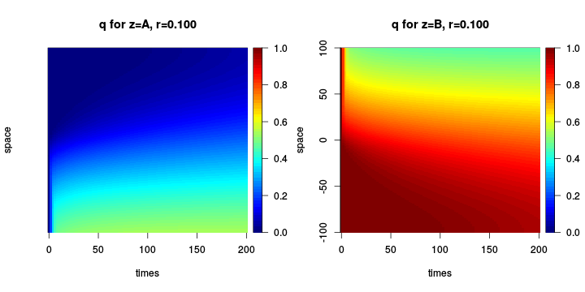

```r
r <- 0.1
s <- 0.1
sigma <- 5
zone.age <- 200  # this is tau
tt <- seq(0,zone.age,length.out=100)
pde.soln <- solve_pde( u=log_u, um1=log_1mu, r=r, times=tt,
                  s=s, sigma=sigma, grid=thegrid, log.u=TRUE )
image(pde.soln,legend=TRUE,main=sprintf("q for z=%s, r=%0.3f",c("A","B"),r), yaxt='n', ylab='space',zlim=c(0,1))
axis(2,at=(pretty(thegrid$x.mid)-min(thegrid$x.mid))/diff(range(thegrid$x.mid)),labels=pretty(thegrid$x.mid))
```

These combine to give the predicted cline:

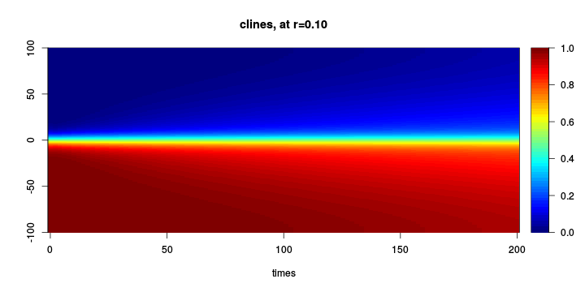

```r
pde.cline <- cline_from_soln(pde.soln,grid=thegrid)
image(pde.cline,legend=TRUE,zlim=c(0,1),main=sprintf("clines, at r=%0.2f",r),yaxt='n')
axis(2,at=(pretty(thegrid$x.mid)-min(thegrid$x.mid))/diff(range(thegrid$x.mid)),labels=pretty(thegrid$x.mid))
```

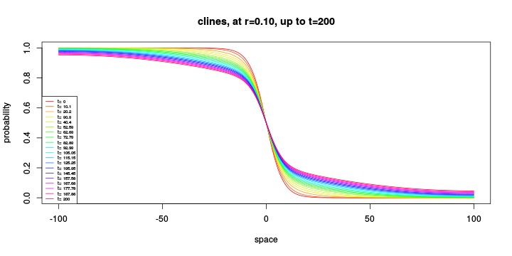

```r
# same thing, plotted with lines
clineplot(pde.cline,x=thegrid$x.mid,main=sprintf("clines, at r=%0.2f, up to t=%d",r,zone.age))
```

**Note:** the range should be wide enough these are *going to zero* at the ends, or else we have to worry about the boundary conditions.

The smaller $r$ is, the slower the per-background probabilities smooth out:

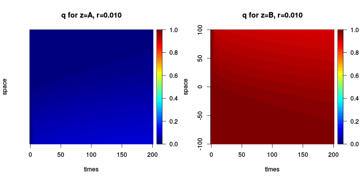

```r
r <- 0.01
pde.soln <- solve_pde( u=log_u, um1=log_1mu, r=r, times=tt,
                  s=s, sigma=sigma, grid=thegrid, log.u=TRUE )
image(pde.soln,legend=TRUE,main=sprintf("q for z=%s, r=%0.3f",c("A","B"),r), yaxt='n', ylab='space',zlim=c(0,1))
axis(2,at=(pretty(thegrid$x.mid)-min(thegrid$x.mid))/diff(range(thegrid$x.mid)),labels=pretty(thegrid$x.mid))
```

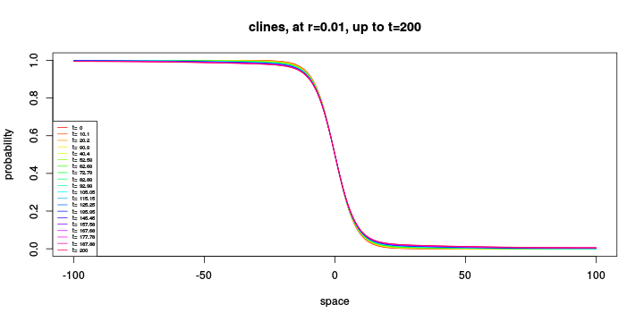

```r
pde.cline <- cline_from_soln(pde.soln,grid=thegrid)
layout(1)
clineplot(pde.cline,x=thegrid$x.mid,main=sprintf("clines, at r=%0.2f, up to t=%d",r,zone.age))
```

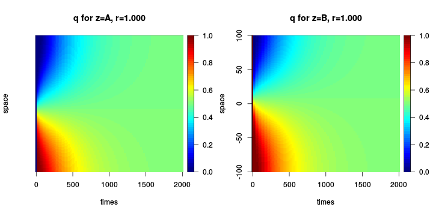

```r
r <- 1.0
zone.age <- 2000  # this is tau
tt <- seq(0,zone.age,length.out=100)
pde.soln <- solve_pde( u=log_u, um1=log_1mu, r=r, times=tt,
                  s=s, sigma=sigma, grid=thegrid, log.u=TRUE )
image(pde.soln,legend=TRUE,main=sprintf("q for z=%s, r=%0.3f",c("A","B"),r), yaxt='n', ylab='space',zlim=c(0,1))
axis(2,at=(pretty(thegrid$x.mid)-min(thegrid$x.mid))/diff(range(thegrid$x.mid)),labels=pretty(thegrid$x.mid))
```

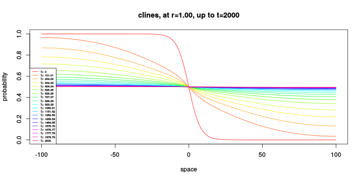

```r
pde.cline <- cline_from_soln(pde.soln,grid=thegrid)
layout(1)
clineplot(pde.cline,x=thegrid$x.mid,main=sprintf("clines, at r=%0.2f, up to t=%d",r,zone.age))
```

# Haplotype lengths

Consider a genomic region $[a,b]$, with the selected site at 0. Recombination without coalescence makes the history of this region a branching process with conserved branching rates. Each branch is labeled by a region of the genome, and moves independently according to generator $G_r$, where $r$ is the distance from the region to the selected site, and branches at rate $w$, where $w$ is its width. We would like to know the probability that *all* branches end up on the same side of the barrier at time $\tau$ in the past.

Suppose that the region includes a type $A$ allele, and we want the probability that it inherits entirely from the $A$ side. Let
$$\begin{aligned}
g(x,A,a,b,\tau) = \P^{x,A}\{ [a,b] \text{ inherits from $A$, $\tau$ generations ago }\} .
\end{aligned}$$
If $W(t)=\{W_1(t),W_2(t),\ldots,W_{n(t)}(t)\}$ is the state of the process $t$ generations ago, where $W_k=(x_k,z_k,a_k,b_k)$, with $x_k$ the position and $W_k\in\{A,B\}$ the allele, then by independence of branches,
$$\begin{aligned}
g(x,A,a,b,0) &= 1 \\
g(x,B,a,b,0) &= 0 \\
g(x,A,a,b,\tau)
&=
\E\left[
\prod_{i=1}^{n(t)} g(x_k,z_k,a_k,b_k,\tau-t)
\right] \qquad \text{for each } t \le \tau .
\end{aligned}$$
Taking $t = \epsilon$ in the last equation, so that the probability of branching is $1-e^{-(b-a)\epsilon}=\epsilon(b-a)+O(\epsilon^2)$, if $0\le a < b$ this implies that
$$\begin{aligned}
\frac{d}{d\tau}
g(x,A,a,b,\tau)
&=
G_{r(a,b)} g(x,A,a,b,\tau)
+
\int_a^b g(x,A,a,\theta,\tau)
\left(
p(x,\tau)g(x,A,\theta,b,\tau)
+ (1-p(x,\tau))g(x,B,\theta,b,\tau)
\right)d\theta
-(b-a)g(x,A,a,b,\tau)
\end{aligned}$$
where
$$\begin{aligned}
r(a,b)=\begin{cases}
\min(|a|,|b|) \qquad &\text{if } ab \ge 0 \\
0 \qquad &\text{if } 0 \in [a,b] .
\end{cases}
\end{aligned}$$
and $G_r f(x,z)$ is defined above. On the other hand, if $a<0<b$, then
$$\begin{aligned}
\frac{d}{d\tau}
g(x,A,a,b,\tau)
&=
G_{r(a,b)} g(x,A,a,b,\tau)
+
\int_0^b g(x,A,a,\theta,\tau)
\left(
p(x,\tau)g(x,A,\theta,b,\tau)
+ (1-p(x,\tau))g(x,B,\theta,b,\tau)
\right)d\theta \\
&\qquad {}
+
\int_a^0 \left(
p(x,\tau)g(x,A,a,\theta,\tau)
+ (1-p(x,\tau))g(x,B,a,\theta,\tau)
\right) g(x,A,\theta,b,\tau) d\theta \\
&\qquad {}
-(b-a)g(x,A,a,b,\tau)
\end{aligned}$$

Writing $g_A$ and $g_B$ for the moment, and dropping $x$ and $\tau$, the generator of the recombination part is, where $x\wedge y=\max(x,y)$ and $x \vee y = \min(x,y)$,
$$\begin{aligned}
Ig_A(a,b)
&=
p \int_{a\wedge 0}^b g_A(a,\theta) g_A(\theta,b) d\theta
+ (1-p) \int_{a\wedge 0}^b g_A(a,\theta) g_B(\theta,b) d\theta
+ p \int_{a}^{b \vee 0} g_A(a,\theta) g_A(\theta,b) d\theta
+ (1-p) \int_{a\wedge 0}^b g_B(a,\theta) g_A(\theta,b) d\theta
\\ &\qquad {}
-(b-a)g_A(a,b) \\
&=
\int_a^b
p \one_{\theta>0} g_A(a,\theta) g_A(\theta,b)
+ (1-p) \one_{\theta>0} g_A(a,\theta) g_B(\theta,b)
+ p \one_{\theta\le0} g_A(a,\theta) g_A(\theta,b)
+ (1-p) \one_{\theta\le0} g_B(a,\theta) g_A(\theta,b) d\theta
\\ &\qquad {}
-(b-a)g_A(a,b) \\
&=
\int_a^b
\left\{
p g_A(a,\theta) g_A(\theta,b)
+ (1-p) \left(
\one_{\theta>0} g_A(a,\theta) g_B(\theta,b)
+ \one_{\theta\le0} g_B(a,\theta) g_A(\theta,b)
\right)
-g_A(a,b) \right\}
d\theta
\end{aligned}$$
$Ig_B$ is the same after exchanging $A$ with $B$, and $p$ with $1-p$.

Therefore, assuming $g$ is sufficiently nice,
$$\begin{aligned}
\frac{d}{d\tau} g(x,z,a,b,\tau)
&=
G_{r(a,b)} g(x,z,a,b,\tau)
+
I g(x,z,a,b,\tau),
\end{aligned}$$
where $I$ is the integral operator defined above. Since $z \in \{A,B\}$, this is a system of two integro-differential equations in three variables plus time ($x$, $a$, $b$, and $\tau$; four if $x\in\R^2$).

*Note:* We also know that
$$\begin{aligned}
g(x,B,a,b,\tau) &= 0 \qquad \text{if } 0 \in [a,b] \\
\end{aligned}$$
but this will have to be arranged by the cline function.

Numerical solutions will discretize; what discretization of the genome might be good? If we want to solve out to time $\tau$, then on a chromosome of length 1 there will be about $\tau$ breakpoints, each of which approximately Exponential($\tau$), and so the smallest distance will have mean $1/\tau^2$. But, suppose we've solved it for time $\tau$, and want to solve it to time $2\tau$. We can use the same discretization, with initial conditions from the first round.

Note that if we think of $u(a,b)$ as a kernel, then the map $u(a,b) \mapsto \int_a^b u(a,\theta) u(\theta,b) d\theta$ is similar to the product of the kernel to itself; on discretization this becomes like a matrix power. This is implemented in some C code.

```r
recomb_generator
```

```
## function (yA, yB, p, zeroind, nabvals, eps)
## {
##     eps * (p * unifprod_ut(y = yA, ncx = nabvals) + (1 - p) *
##         biprod_ut(yA = yA, yB = yB, zeroind = zeroind, ncx = nabvals))
## }
```

```r
s <- 0.1
tt <- seq(0,10,length.out=20)

xgrid <- setup.grid.1D(x.up=-20, x.down=20, N=21)
rgrid <- setup.grid.1D(x.up=-0.5, x.down=0.5, N=40)

hap.soln <- forwards_backwards_haplotypes(s=s, times=tt, xgrid=xgrid, rgrid=rgrid)
```

Here are haplotype probabilities centered on the selected site:

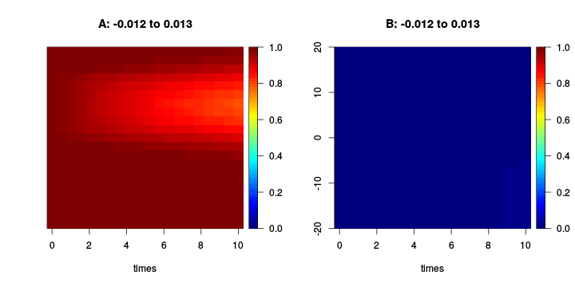

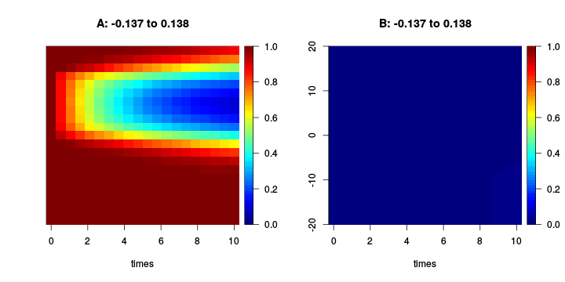

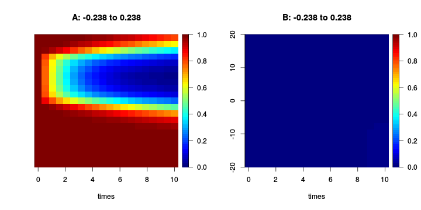

```r
for (haplen in c(0.02, 0.26, 0.46)) {
    hap.probs <- get_hap_probs( hap.soln, left=-haplen/2, right=haplen/2 )
    image( hap.probs, zlim=c(0,1), legend=TRUE, yaxt='n',
          main=paste(c("A:","B:"),paste(round(attr(hap.probs,"r"),3),collapse=" to ")) )
    axis(2,at=(pretty(xgrid$x.mid)-min(xgrid$x.mid))/diff(range(xgrid$x.mid)),labels=pretty(xgrid$x.mid))
}
```

And, here are haplotype probabilities for a fairly short haplotype moving away from the selected site:

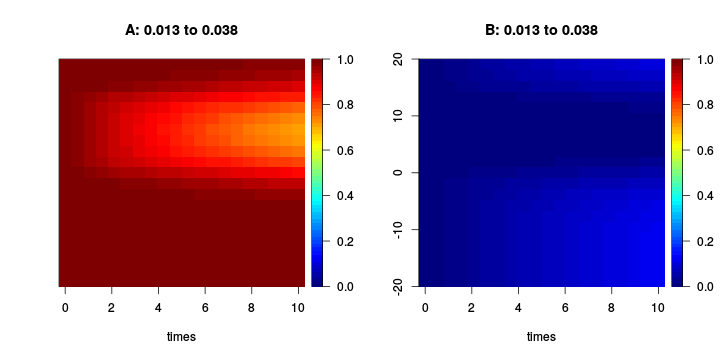

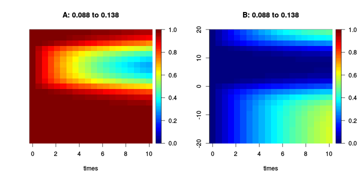

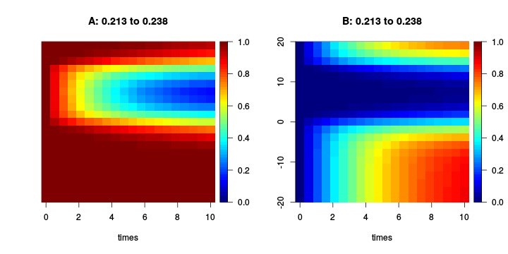

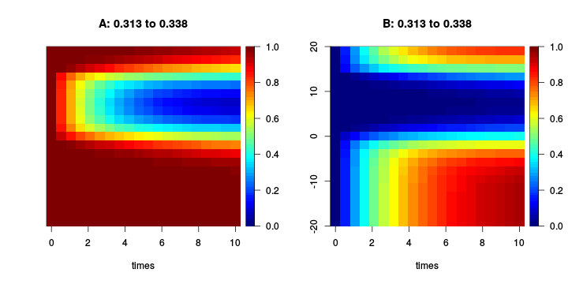

```r
haplen <- 0.04
for (haploc in c(0.01, 0.09, 0.21, 0.31)) {
    hap.probs <- get_hap_probs( hap.soln, left=haploc, right=haploc+haplen )
    image( hap.probs, zlim=c(0,1), legend=TRUE, yaxt='n',
          main=paste(c("A:","B:"),paste(round(attr(hap.probs,"r"),3),collapse=" to ")) )
    axis(2,at=(pretty(xgrid$x.mid)-min(xgrid$x.mid))/diff(range(xgrid$x.mid)),labels=pretty(xgrid$x.mid))
    locator(1)
}
```

Here's all the solution traces, i.e., how probabilities of inheriting an $A$ haplotype of all lengths, positions, and spatial locations changes with time

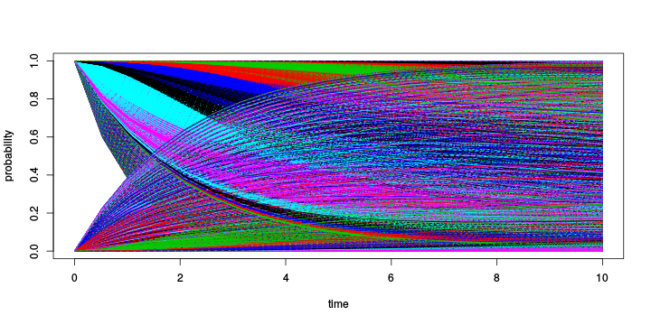

```r
matplot(hap.soln[,1],hap.soln[,-1],type='l',xlab='time',ylab='probability')
```

Here's how these look across space, at a fixed time, with line type showing haplotype length and color showing distance to the selected site.

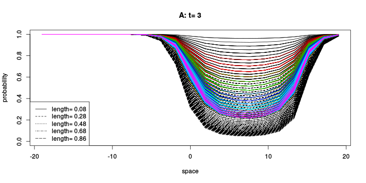

```r
plot.t <- 3
hap.clines <- hap.soln[which(hap.soln[,1]>=plot.t)[1],-1]
dim(hap.clines) <- attr(hap.soln,"soln.dims")
r.df <- data.frame(attr(hap.soln,"r"))
r.df$length <- r.df$right-r.df$left
r.df$dist <- ifelse(r.df$right*r.df$left>0,pmin(abs(r.df$right),abs(r.df$left)),0)
r.df$col <- as.numeric(cut(r.df$dist,6))
r.df$lty <- as.numeric(cut(r.df$length,5))
matplot(xgrid$x.mid,hap.clines[1:xgrid$N,],type='l',main=paste("A: t=",plot.t),ylim=c(0,1),xlab="space",col=r.df$col,lty=r.df$lty,ylab="probability")
legend("bottomleft",lty=unique(r.df$lty),legend=paste("length=",round(tapply(r.df$length,r.df$lty,mean),2)))
```

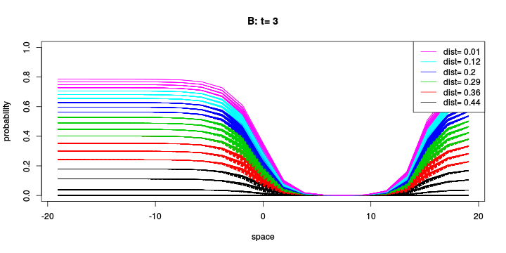

```r
matplot(xgrid$x.mid,hap.clines[xgrid$N+1:xgrid$N,],type='l',main=paste("B: t=",plot.t),ylim=c(0,1),xlab="space",col=r.df$col,lty=r.df$lty,ylab="probability")
legend("topright",lty=1,col=unique(r.df$col),legend=paste("dist=",round(tapply(r.df$dist,r.df$col,mean),2)))
```

And, here's a heatmap of haplotype length across space and time: shown is the longest haplotype length that has probability of at least 50% of coming entirely from $A$:

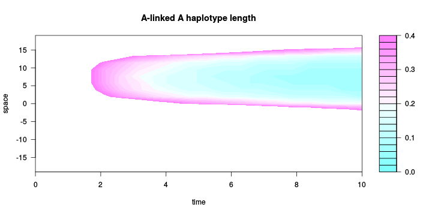

```r
xfac <- rep(1:xgrid$N,nrow(r.df))
ABfac <- rep( rep(c("A","B"),each=xgrid$N), nrow(r.df) )
hap.lens <- lapply( c(A="A",B="B"), function (allele) {
    do.call( rbind, lapply( 1:nrow(hap.soln), function (k) {
            tapply( hap.soln[k,1+which(ABfac==allele)], xfac, function (xx) {
                   if(any(xx>0.5)) { max(r.df$length[xx>0.5]) } else { 0.0 }
                } )
        } ) )
    } )
filled.contour(hap.soln[,1],xgrid$x.mid,hap.lens$A,xlab="time",ylab="space",zlim=c(0,max(hap.lens$B)),main="A-linked A haplotype length")
```

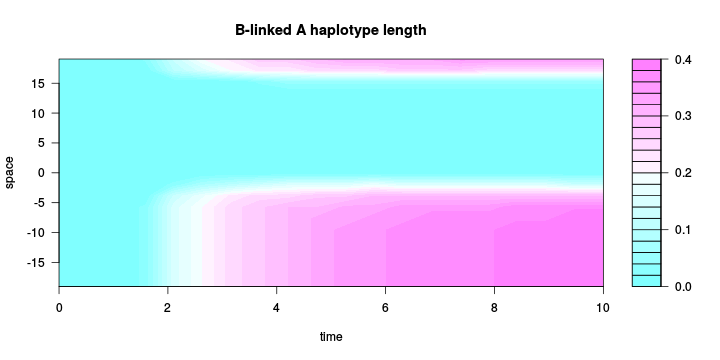

```r
filled.contour(hap.soln[,1],xgrid$x.mid,hap.lens$B,xlab="time",ylab="space",zlim=c(0,max(hap.lens$B)),main="B-linked A haplotype length")
```

# Linkage

The way the discretization for haplotypes is implemented effectively only keeps track of a finite number of markers. To do two-site ancestral LD, then, we just need to use the above code at only two sites on the genome.

First, we compute per-allele solutions:

```r
s <- 0.1
tt <- seq(0,100,length.out=21)
xgrid <- setup.grid.1D(x.up=-20.5, x.down=20.5, N=41)
rr <- seq(0,0.5,length.out=20)[-1]
fgrid <- extend_grid(xgrid)
fwds.soln <- forwards_pde(s=s,times=tt,grid=fgrid)
LD.solns <- lapply( rr, function (r) forwards_backwards_haplotypes(s=s, times=tt, xgrid=xgrid, rgrid=list(x.mid=c(0,r),N=2), fwds.soln=fwds.soln) )
```

... but then we must extract linkage from these. Below we report for recombination distance $r$, the probability that two markers at distance $r$ sampled in one individual at that location and time (with one end fixed to the selected site) are both of the same ancestral type. If the local proportion of type $A$ is $p$ and the probability when linked to $A$ is $u_A$, we want $p u_A(r_0,r_0+r) + (1-p) u_B(r_0,r_0+r) - (p u_A(r_0) + (1-p) u_A(r_0))(p u_A(r_0+r) + (1-p) u_A(r_0+r))$:

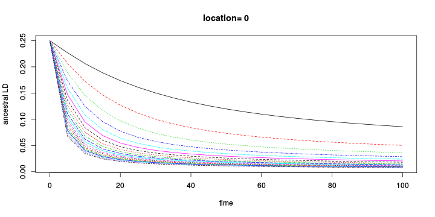

```r
pfun <- function (t,x) {
        fp <- function (x,t) { approx(fgrid$x.mid,cline_interp(t,soln=fwds.soln),xout=x)$y }
        ans <- numeric(length(x))
        for (tval in unique(t)) {
            dothese <- (rep_len(t,length(x))==tval)
            ans[dothese] <- fp(x=x[dothese],t=tval)
        }
        return(ans)
}
ABfac <- rep( rep(c("A","B"),each=xgrid$N), 3 )  # three combinations of two recomb points
rfac <- rep( c("11","12","22"), each=xgrid$N*2 )
LDs <- lapply( LD.solns, function (lds) {
            # returns a time x space matrix
            pp <- outer( lds[,1], xgrid$x.mid, pfun )
            return(
                   pp * lds[,1+which(ABfac=="A"&rfac=="12")] + (1-pp) * lds[,1+which(ABfac=="B"&rfac=="12")]
                   - ( pp * lds[,1+which(ABfac=="A"&rfac=="11")] + (1-pp) * lds[,1+which(ABfac=="B"&rfac=="11")] )
                       * ( pp * lds[,1+which(ABfac=="A"&rfac=="22")] + (1-pp) * lds[,1+which(ABfac=="B"&rfac=="22")] )
               )
    } )
plot.x <- xgrid$x.mid[which.min(abs(xgrid$x.mid))]
matplot( tt, sapply( LDs, function (x) { x[,match(plot.x,xgrid$x.mid)] } ), type='l', ylab="ancestral LD", xlab="time", main=paste("location=",round(plot.x,2)) )
```

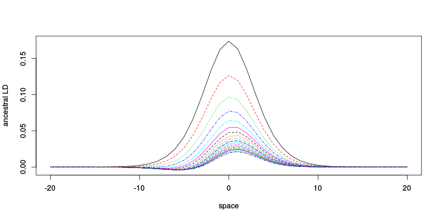

```r
plot.t <- tt[which.min(abs(tt-20))]
matplot( xgrid$x.mid, sapply( LDs, function (x) { x[match(plot.t,tt),] } ), type='l', ylab="ancestral LD", xlab="space" )
```

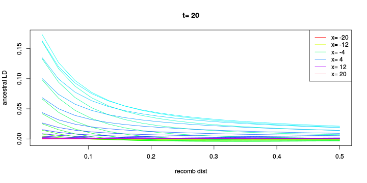

```r
matplot( rr, t(sapply( LDs, function (x) { x[match(plot.t,tt),] } )), type='l', ylab="ancestral LD", xlab="recomb dist", main=paste("t=",round(plot.t,2)), col=rainbow(xgrid$N), lty=1 )
legend("topright",lty=1,col=rainbow(xgrid$N)[floor(seq(1,xgrid$N,length.out=6))],legend=paste("x=",round(xgrid$x.mid[floor(seq(1,xgrid$N,length.out=6))],2)))
```

Hm, the right/left spatial positions should look the same, right? Is something off?

**Note:** do the same with fixed distance between the two and changing distance to selected locus.

# Distance to closest recombination in a heterozygote

A simpler statistic, that might approximate haplotype statistics well, is the distance along the chromosome from an $A$ allele until the closest recombination that occurred in an $AB$ heterozygote. Let $H$ be this distance; then,
$$\begin{aligned}
u(x,\tau,r)=\P^{(x,\tau)}\{H>r\}
\end{aligned}$$
solves the following PDE:
$$\begin{aligned}
u(x,0,r) &= 1 \\
\partial_t u(x,t,r)
&=
\grad \log(p(x)) \cdot \grad u(x,t,r) + \frac{\sigma^2}{2} \Delta u(x,t,r) - r (1-p(x)) u(x,t,r) .
\end{aligned}$$

# Comparison to simulation

We'll setup, run, and summarize simulations as described in this file.

```r
source("../sims/sim-fns.R")
zone.age    = 50
ndemes      = 500
deme.size   = 5
ninds       = ndemes*deme.size
qtl         = list(chr1=data.frame(traits=c("underdominant"), s = s, pos=c(0.5)))
# spatial locations
xx <- (1:ndemes)-0.5-ndemes/2
# run the simulation
sim <- sim.zone(n.gen=zone.age,n.ind=ninds,n.deme=ndemes,sigma=sigma,quiet=TRUE)
# post-process
sim.sums <- spBreaks(sim)
```

and, postprocess:

```r
rvals <- c(0,exp(seq(log(.001),log(0.5),length.out=10)))
loci <- list(0.5+c(rev(rvals[-1]),-rvals))
genotypes <- data.frame(do.call(cbind,lapply(sim.sums$ind.ancest, geno.ind, loci)))
freqs <- apply(genotypes,1,function(Z){
            tapply(Z,cut(1:ncol(genotypes),breaks=seq(0,ncol(genotypes),deme.size)),mean)/2
        })
```

OK, now let's match the PDE solution to the simulation. First, does the cline at the selected locus match the the tanh cline?

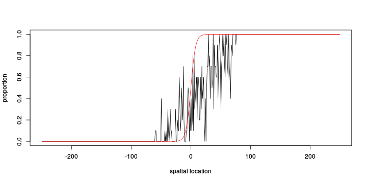

```r
plot(xx,freqs[,1],type='l',xlab="spatial location",ylab="proportion")
lines(xx,1-tanh_cline(xx,s=s,sigma=sigma),col='red')
```

Here's the PDE solution:

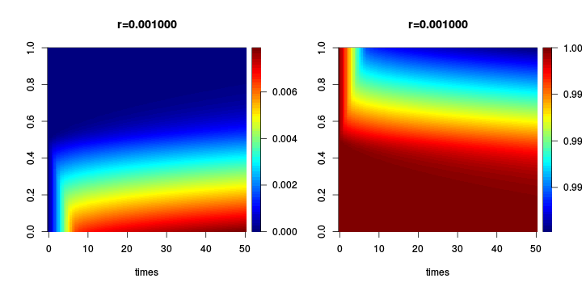

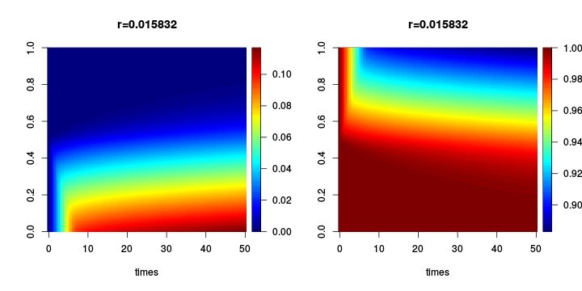

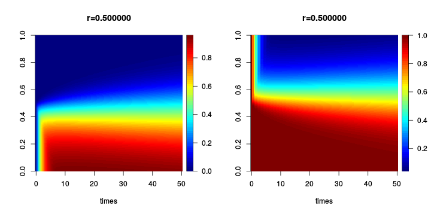

```r
zone.age <- sim$pars["n.gen"]
tt <- seq(0,zone.age,length.out=100)
pde.solns <- lapply(rvals, function (r) { solve_pde( u=log_u, um1=log_1mu, r=r, times=tt,
                                                s=s, sigma=sigma, grid=thegrid, log.u=TRUE ) } )
pde.clines <- lapply( pde.solns, cline_from_soln, grid=thegrid )
match.clines <- sapply(pde.clines,function(x)x[length(tt),-1])
for (k in floor(seq(2,length(rvals),length.out=3))) {
    image(pde.solns[[k]],legend=TRUE,main=sprintf("r=%f",rvals[k]))
}
```